# Important Imports

```python
import numpy as np
import cv2
import gzip
from matplotlib import pyplot as plt
import math
from sklearn.linear_model import LogisticRegression
from sklearn.neural_network import MLPClassifier
```

# Loading Data

The following 2 blocks are helper functions for loading up the dataset and the last block loads up the data.

```python
#This method takes in a file name and loads it up into a numpy array.
#is_img indicates if the file is for images, which makes a np array of shape (num_ex x num_image_rows x num_image_cols)
#the second numpy array is the labels, which is num_ex x 1
def mnist_to_np(f_name, is_img = False):
    with gzip.open(f_name) as mnist:
        #for information about loading up mnist refer to http://yann.lecun.com/exdb/mnist/
        magic_num = int.from_bytes(mnist.read(4), byteorder='big', signed=False) #first int is the magic number
        num_ex = int.from_bytes(mnist.read(4), byteorder='big', signed=False) #second int is the number of examples
        if is_img == True:
            rows = int.from_bytes(mnist.read(4), byteorder='big', signed=False) #if it is an image then the 3rd integer is for num_rows
            cols = int.from_bytes(mnist.read(4), byteorder='big', signed=False) #if it is an image then the 4th integer is for num_columns
        if is_img == True:
            data = np.array(list(mnist.read(num_ex * rows * cols))).reshape(num_ex, rows, cols) #reshapes the data to the appropriate image shape
        else:
            data = np.array(list(mnist.read(num_ex))).reshape(num_ex, 1) #this just reads the examples as
        return data
```

```python
#loads up the mnist data set into a numpy array where axis=0 is the number of examples
#the first numpy array is the images, which is of shape num_ex x num_image_rows x num_image_cols
#the second numpy array is the labels, which is of shape num_ex x 1
def mnist_to_data(name):
    return (mnist_to_np(name + "_images.gz", is_img = True), mnist_to_np(name + "_labels.gz"))
```

```python
train = mnist_to_data("train") # a tuple of training images and labels
test = mnist_to_data("test") # a tuple of testing images and labels

train_images = train[0]
train_labels = train[1]
test_images = test[0]
test_labels = test[1]

num_train_ex = train_images.shape[0]
num_test_ex = test_images.shape[0]
image_shape = train_images[0].shape
num_labels = train_labels.max() + 1 # number of labels/classes

print("Number of training examples: " + str(num_train_ex))
print("Number of testing examples: " + str(num_test_ex))
print("Image shape: " + str(image_shape))
print("Number of labels: " + str(num_labels))
```

```
Number of training examples: 60000
Number of testing examples: 10000
Image shape: (28, 28)
Number of labels: 10
```

# Ideal Images

This function converts an examples in an image matrix to a single image. This is what will be the "ideal image". The ideal_images method organizes each image class into the corresponding index in the ideal_images_list.

The last block converts the training data into the ideal images and stores the labels into a variable named labels.

```python
#sums all the images into a single image and then normalizes it by dividing it by the highest pixel value
#then multiplies each image by 255.
def norm_sum_images(images):
    raw_sum = np.mean(images, axis = 0)
    #norm_sum = (raw_sum / np.max(raw_sum))*255
    norm_sum = raw_sum
    return norm_sum
```

```python
def ideal_images(images, labels = None):

    if labels is None:
        labels = images[1]
        images = images[0]

    ideal_image_list = []
    #the for loop goes through 0 to 9 because there are 10 classes, each labeled 0-9
    for l in range(num_labels):
        l_images = images[labels[:,0] == l]
        ideal_image_list.append(norm_sum_images(l_images).astype(np.uint8))

    return ideal_image_list
```

```python
ideal_image_list = ideal_images(train)
```

# Displaying Images

The following 2 methods are for displaying images.

The last block displays the ideal images.

```python
def show_img(image):
    plt.imshow(image.astype(np.uint8))
```

```python
def show_img_list(image_list):
    num_img = len(image_list)

    rows = math.ceil(math.sqrt(num_img))
    cols = math.floor(math.sqrt(num_img))
    fig = plt.figure(figsize = (10, 10))

    for i in range(0, num_img):
        fig.add_subplot(rows, cols, i+1)
        img = image_list[i].astype(np.uint8)
        show_img(img)
plt.show()
```

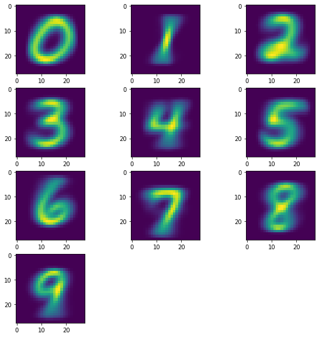

```python
show_img_list(ideal_image_list)
```

# Prediction making

The following methods are made to calculate predictions of images based on the similarity to the ideal images. Similar to k-nearest neighbor, but only comparing it to the ideal images.

```python
#This method calculates the difference between the image and ideal image.
#You are welcome to mess around with this method to see if you can find a
#better way to compare.
def square_dif(image, ideal_image):

    dif = (image-ideal_image).astype(np.float32)

    return (dif ** 4)/(255**3)
```

```python
#This method determines how close the images are and assigns a
#score for each example
def score(image, ideal_image):
    dif = square_dif(image, ideal_image).reshape(image.shape[0], -1)
    #the reshape made the image array into shape (num_ex, rows*cols)
    dif = np.sqrt(np.sum(dif, axis = 1, keepdims = True)) #sum along the image axis

    return 1/(dif)
```

```python
def score_labels(images, ideal_image_list):
    scores = []
    for l in range(num_labels):
         #calculates the score compared to this label's ideal image
        scores.append(score(images, ideal_image_list[l]).reshape(-1))
    return np.array(scores)
```

```python
def determine_labels(images, ideal_image_list):
    scores = score_labels(images, ideal_image_list)

    #this finds the index of the max element along the label-axis
    max_scores = scores.argmax(axis=0)

    return max_scores
```

# Analysis Methods

These methods are used to analyse how well the algorithm is performing in simple terms

```python
def accuracy(actual_labels, predicted_labels):
    correct = actual_labels.reshape(-1) == predicted_labels.reshape(-1)

    return np.sum(correct) / actual_labels.shape[0]
```

```python
predicted_train_labels = determine_labels(train_images, ideal_image_list)
predicted_test_labels = determine_labels(test_images, ideal_image_list)
print("Train Accuracy: " + str(accuracy(train_labels, predicted_train_labels)*100) + "%")
print("Test Accuracy: " + str(accuracy(test_labels, predicted_test_labels)*100) + "%")
```

```
Train Accuracy: 80.965%
Test Accuracy: 82.03%
```

# Check out what the ideal image does

Label_c is the class for the ideal image used in the square difference.

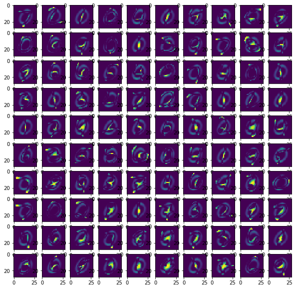

```python
label_c = 0
train_dif = square_dif(train_images, ideal_image_list[0])
test_dif = square_dif(test_images, ideal_image_list[0])
show_img_list(test_dif[0:100].reshape(100, 28, 28))
```

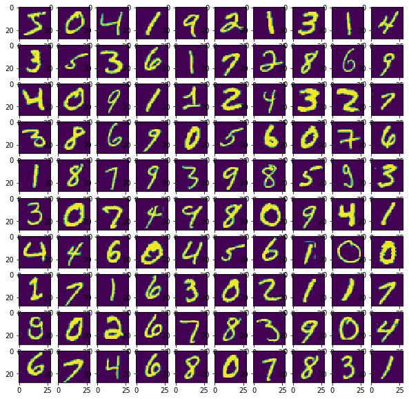

```python
show_img_list(train_images[0:100])
```

# Other Models

Compare the performance to other, more mainstream models.

```python
def format_for_model(images, labels):
    m = labels.shape[0] #number of examples
    #X = np.zeros((m, labels.max()+1))

    #X[np.arange(m), predicted_labels] = 1
    X = images.reshape(m, -1)/255
    Y = labels.reshape(m)
    print("X Shape: " + str(X.shape))
    print("Y Shape: " + str(Y.shape))
    return X, Y
```

```python
def logistic_regression(images, labels):
    X, Y = format_for_model(images, labels)
    print("Started training...")
    model = LogisticRegression(random_state=0, C = 0.01).fit(X, Y)
    print("Finished training...")
    return model
```

```python
def neural_network(images, labels):
    X, Y = format_for_model(images, labels)
    print("Started training...")
    model = MLPClassifier(learning_rate_init=3e-3, hidden_layer_sizes=(56, 28, 14), random_state=0, alpha = 0.1).fit(X, Y)
    print("Finished training...")
    return model
```

```python
def model_predict(model, images):
    return model.predict(images.reshape(images.shape[0],-1)/255)
```

```python
logistic_model = logistic_regression(train_images, train_labels)

train_prediction = model_predict(logistic_model, train_images)
print("Training Accuracy: " + str(accuracy(train_labels, train_prediction)))
test_prediction = model_predict(logistic_model, test_images)
print("Testing Accuracy: " + str(accuracy(test_labels, test_prediction)))
```

```
X Shape: (60000, 784)
Y Shape: (60000,)
Started training...
```

```
Finished training...
Training Accuracy: 0.9185333333333333
Testing Accuracy: 0.9189
```

```python
neural_model = neural_network(train_images, train_labels)

train_prediction = model_predict(neural_model, train_images)
print("Training Accuracy: " + str(accuracy(train_labels, train_prediction)))
test_prediction = model_predict(neural_model, test_images)
print("Testing Accuracy: " + str(accuracy(test_labels, test_prediction)))
```

```
X Shape: (60000, 784)
Y Shape: (60000,)
Started training...
Finished training...
Training Accuracy: 0.9870666666666666
Testing Accuracy: 0.973
```